# Stat 135: Lab Project

Zubair Marediya, Temi Lal, Charles Thorson

Tuesday, May 05, 2015

Before beginning any part of this project, let's import our data.

```r
data = read.csv("diabetes.csv")
```

The last 16 patients were held out for testing, so we will remove them from our data.

```r
data = data[1:359, ]
```

# Part 2: Accessing Data, Visualization and Summarization

## Question 1

Let's create the histogram first. We will use ggplot2 for all visuals.

```r
glyhb = data$glyhb
require("ggplot2")
```

```r
## Loading required package: ggplot2
```

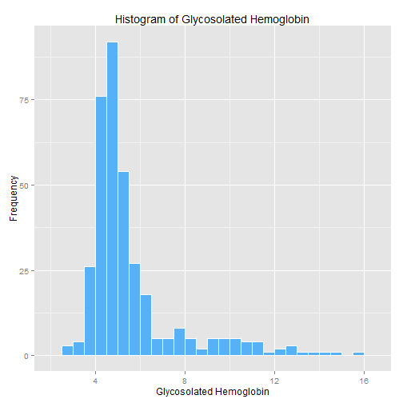

```r
ggplot(data) + geom_histogram(aes(x = glyhb), binwidth = 0.5, col = "white", fill = "#56B1F7") +
  ggtitle("Histogram of Glycosolated Hemoglobin") +
  xlab("Glycosolated Hemoglobin") + ylab("Frequency")
```

Now let's create the boxplot.

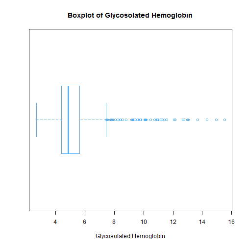

```r
boxplot(glyhb, horizontal = TRUE, col = "white", border = "#56B1F7",
        xlab = "Glycosolated Hemoglobin",
        main = "Boxplot of Glycosolated Hemoglobin")
```

Lastly let's create the qqplot.

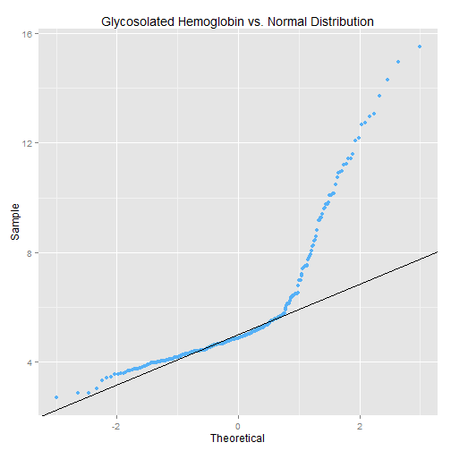

```r
exp.sample = rnorm(n = 10000)
y1y2 = quantile(glyhb, probs = c(0.25, 0.75))
x1x2 = quantile(exp.sample, probs = c(0.25, 0.75))
slope = (y1y2[2] - y1y2[1])/(x1x2[2] - x1x2[1])
intercept = slope * (0 - x1x2[1]) + y1y2[1]
ggplot(data, aes(sample = glyhb)) + stat_qq(col = "#56B1F7") +
  ggtitle("Glycosolated Hemoglobin vs. Normal Distribution") +
  xlab("Theoretical") +
  ylab("Sample") +
  geom_abline(intercept = intercept, slope = slope)
```

From seeing all three visuals above, we see that the distribution is skewed to the right with a heavy tail. Thus, it does not follow a Gaussian distribution. The boxplot shows us that there are many outliers. The center seems to be around 5, and the bulk of the data falls between 4 and 6. Our qq-plot follows a normal well until we hit the value of 1 on the Theoretical axis. At that point, our outliers kick in, and we do not follow a Gaussian distribution anymore. It seems there are a few people with very high levels of Glycosolated Hemoglobin. We might suspect that these people are in poor health and have Type II diabetes.

## Question 2

Now let's repeat this for cholesterol.

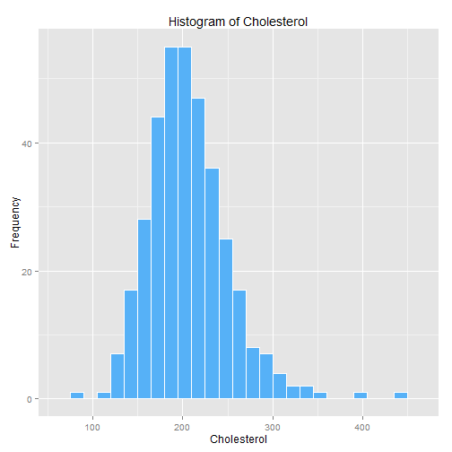

```r
chol = data$chol

# Produce the histogram

ggplot(data) + geom_histogram(aes(x = chol), binwidth = 15, col = "white", fill = "#56B1F7") +
  ggtitle("Histogram of Cholesterol") +
  xlab("Cholesterol") + ylab("Frequency")
```

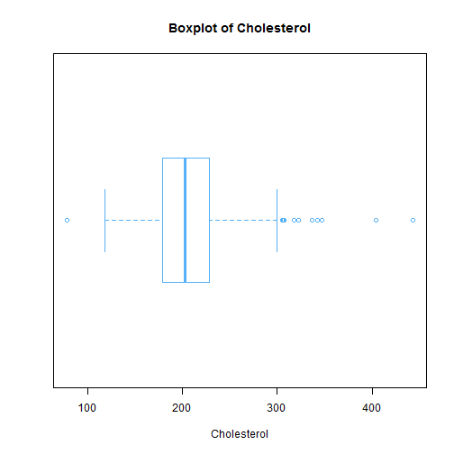

```r
# Produce the boxplot

boxplot(chol, horizontal = TRUE, col = "white", border = "#56B1F7",
        xlab = "Cholesterol",
        main = "Boxplot of Cholesterol")
```

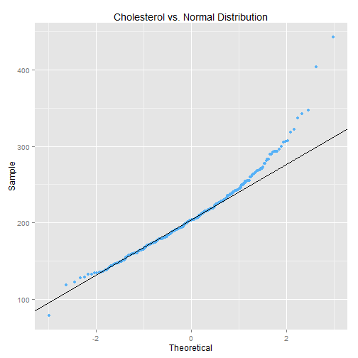

```r
# Produce the qq-plot

exp.sample = rnorm(n = 10000)
y1y2 = quantile(chol, probs = c(0.25, 0.75))
x1x2 = quantile(exp.sample, probs = c(0.25, 0.75))
slope = (y1y2[2] - y1y2[1])/(x1x2[2] - x1x2[1])
intercept = slope * (0 - x1x2[1]) + y1y2[1]
ggplot(data, aes(sample = chol)) + stat_qq(col = "#56B1F7") +
  ggtitle("Cholesterol vs. Normal Distribution") +
  xlab("Theoretical") +
  ylab("Sample") +
  geom_abline(intercept = intercept, slope = slope)
```

The histogram for Cholesterol looks fairly Gaussian centered around 200. There are some outliers above 400 and one low outlier below 100. When you compare the boxplot to that of Glycosolated Hemoglobin, you see that there are fewer outliers. When observing the qq-plot, the data follows the Gaussian distribution fairly well, with the exception of a few outliers.

Overall, cholesterol is better approximated with Gaussian distribution than Glycosolated Hemoglobin.

## Question 3

First let's make the scatterplot of bp.1s vs. bp.1d.

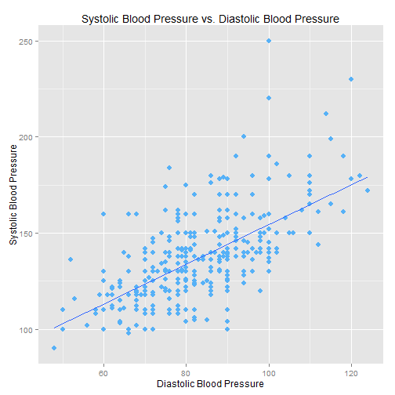

```r
ggplot(data, aes(x = bp.1d, y = bp.1s)) +
    geom_point(shape = 16, col = "#56B1F7", size = 3) +
    geom_smooth(method = lm, se = FALSE) +
    xlab("Diastolic Blood Pressure") +
    ylab("Systolic Blood Pressure") +
    ggtitle("Systolic Blood Pressure vs. Diastolic Blood Pressure")
```

Now let's make the scatterplot of age vs. height.

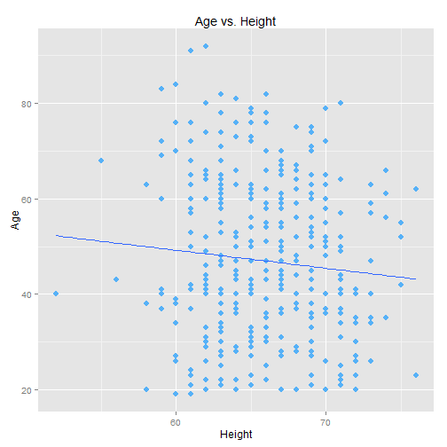

```r
ggplot(data, aes(x = height, y = age)) +
    geom_point(shape = 16, col = "#56B1F7", size = 3) +
    geom_smooth(method = lm, se = FALSE) +
    xlab("Height") +
    ylab("Age") +
    ggtitle("Age vs. Height")
```

Observing the first scatterplot shows a fair increase in Systolic Blood Pressure (bp.1s) as Diastolic Blood Pressure (bp.1d) increases. A slight linear relationship is evident, thus these features do not seem independent.

Observing the second scatterplot shows no relationship between the two variables. The plot shows random scatter, and the regression line is fairly horizontal. This is what we would expect because everyone in our sample is 19 years or older, and wtihin this age bracket, people are usually fully grown, so we conclude that these features are independent.

## Question 4

First let's make a logical vector in our "data" data frame that's conditional on whether glyhb >= 7 or glyhb < 7.

```r
diabetes_locs = glyhb >= 7
diabetes = c()
diabetes[diabetes_locs] = "Greater than or equal to 7 (Diabetes)"
diabetes[!diabetes_locs] = "Less than 7 (No Diabetes)"
data$diabetes = factor(diabetes)
```

Now let's begin making boxplots for each available feature conditional on the statement above.

Let's first make conditional boxplots for Cholesterol.

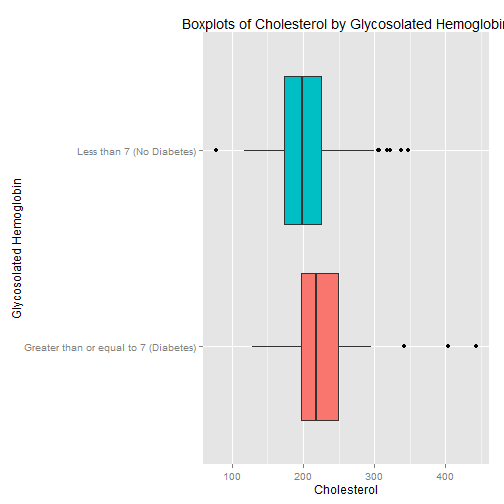

```r
ggplot(data, aes(x = diabetes, y = chol)) +
  geom_boxplot(aes(fill = diabetes)) +
  coord_flip() +
  theme(legend.position="none") +
  ylab("Cholesterol") +
  xlab("Glycosolated Hemoglobin") +
  ggtitle("Boxplots of Cholesterol by Glycosolated Hemoglobin")
```

Now let's make them for Stabilized Glucose.

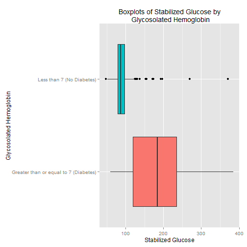

```r
ggplot(data, aes(x = diabetes, y = stab.glu)) +
  geom_boxplot(aes(fill = diabetes)) +
  coord_flip() +
  theme(legend.position="none") +
  ylab("Stabilized Glucose") +
  xlab("Glycosolated Hemoglobin") +
  ggtitle("Boxplots of Stabilized Glucose by\n Glycosolated Hemoglobin")
```

Now let's make them for High Density Lipoprotein.

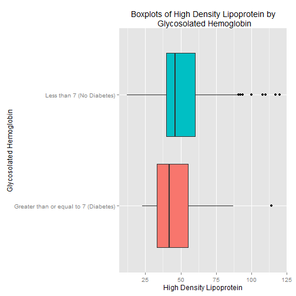

```r
ggplot(data, aes(x = diabetes, y = hdl)) +
  geom_boxplot(aes(fill = diabetes)) +
  coord_flip() +
  theme(legend.position="none") +
  ylab("High Density Lipoprotein") +
  xlab("Glycosolated Hemoglobin") +
  ggtitle("Boxplots of High Density Lipoprotein by\n Glycosolated Hemoglobin")
```

Now let's make them for Ratio (chol/hdl).

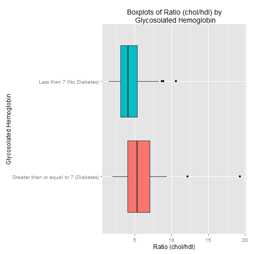

```r
ggplot(data, aes(x = diabetes, y = ratio)) +
  geom_boxplot(aes(fill = diabetes)) +
  coord_flip() +
  theme(legend.position="none") +
  ylab("Ratio (chol/hdl)") +
  xlab("Glycosolated Hemoglobin") +
  ggtitle("Boxplots of Ratio (chol/hdl) by\n Glycosolated Hemoglobin")
```

Now let's make them for Age.

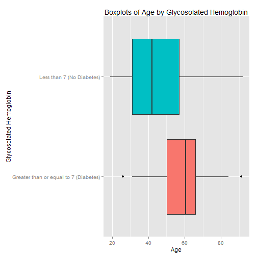

```r
ggplot(data, aes(x = diabetes, y = age)) +
  geom_boxplot(aes(fill = diabetes)) +
  coord_flip() +
  theme(legend.position="none") +
  ylab("Age") +
  xlab("Glycosolated Hemoglobin") +
  ggtitle("Boxplots of Age by Glycosolated Hemoglobin")
```

Now let's make them for Height.

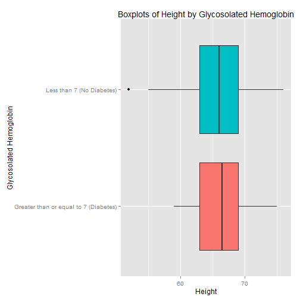

```r
ggplot(data, aes(x = diabetes, y = height)) +
  geom_boxplot(aes(fill = diabetes)) +
  coord_flip() +
  theme(legend.position="none") +
  ylab("Height") +
  xlab("Glycosolated Hemoglobin") +
  ggtitle("Boxplots of Height by Glycosolated Hemoglobin")
```

Now let's make them for Weight.

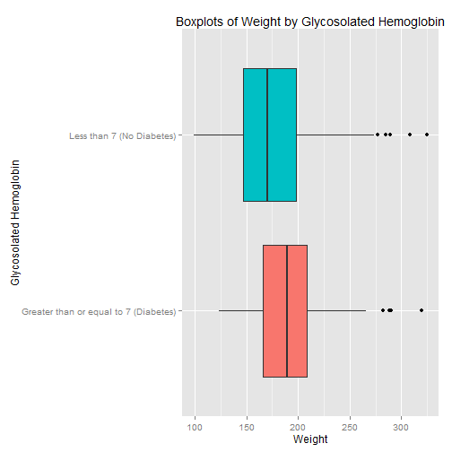

```r
ggplot(data, aes(x = diabetes, y = weight)) +
  geom_boxplot(aes(fill = diabetes)) +
  coord_flip() +
  theme(legend.position="none") +
  ylab("Weight") +
  xlab("Glycosolated Hemoglobin") +
  ggtitle("Boxplots of Weight by Glycosolated Hemoglobin")
```

Now let's make them for Systolic Blood Pressure.

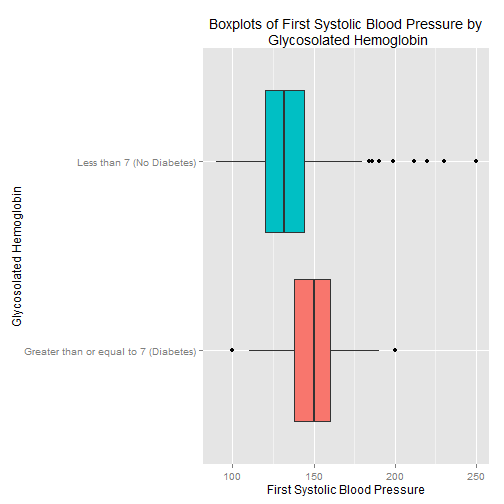

```r
ggplot(data, aes(x = diabetes, y = bp.1s)) +
  geom_boxplot(aes(fill = diabetes)) +
  coord_flip() +
  theme(legend.position="none") +
  ylab("First Systolic Blood Pressure") +
  xlab("Glycosolated Hemoglobin") +
  ggtitle("Boxplots of First Systolic Blood Pressure by\n Glycosolated Hemoglobin")
```

Now let's make them for Diastolic Blood Pressure.

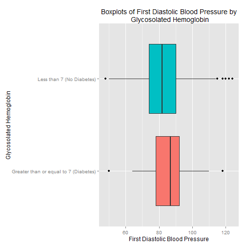

```r
ggplot(data, aes(x = diabetes, y = bp.1d)) +
  geom_boxplot(aes(fill = diabetes)) +
  coord_flip() +
  theme(legend.position="none") +
  ylab("First Diastolic Blood Pressure") +
  xlab("Glycosolated Hemoglobin") +
  ggtitle("Boxplots of First Diastolic Blood Pressure by\n Glycosolated Hemoglobin")
```

Now let's make them for Waist size.

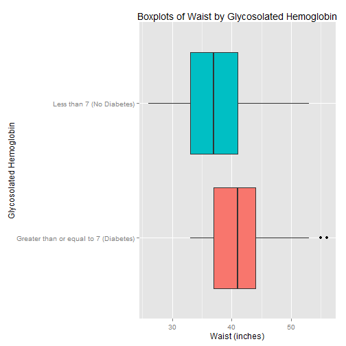

```r
ggplot(data, aes(x = diabetes, y = waist)) +
  geom_boxplot(aes(fill = diabetes)) +
  coord_flip() +
  theme(legend.position="none") +
  ylab("Waist (inches)") +
  xlab("Glycosolated Hemoglobin") +
  ggtitle("Boxplots of Waist by Glycosolated Hemoglobin")
```

Now let's make them for Hip size.

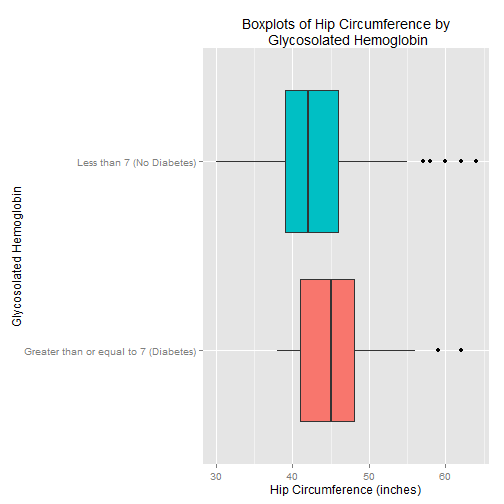

```r
ggplot(data, aes(x = diabetes, y = hip)) +
  geom_boxplot(aes(fill = diabetes)) +
  coord_flip() +
  theme(legend.position="none") +
  ylab("Hip Circumference (inches)") +
  xlab("Glycosolated Hemoglobin") +
  ggtitle("Boxplots of Hip Circumference by\n Glycosolated Hemoglobin")
```

Now let's make them for Frame size. We have some blanks in our data for this variable, so we will first remove those. We will add a dotted line for Glyhb = 7, so we know where we classify by diabetes.

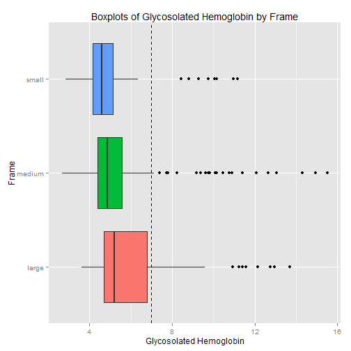

```r
ggplot(data[data$frame != "", ], aes(x = frame, y = glyhb)) +
  geom_boxplot(aes(fill = frame)) +
  coord_flip() +
  theme(legend.position="none") +
  ylab("Glycosolated Hemoglobin") +
  xlab("Frame") +
  ggtitle("Boxplots of Glycosolated Hemoglobin by Frame") +
  geom_hline(yintercept = 7, linetype = "dashed")
```

Now let's make them for Postprandial Time.

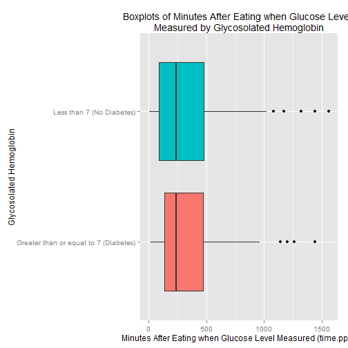

```r
ggplot(data, aes(x = diabetes, y = time.ppn)) +
  geom_boxplot(aes(fill = diabetes)) +
  coord_flip() +
  theme(legend.position="none") +
  ylab("Minutes After Eating when Glucose Level Measured (time.ppn)") +
  xlab("Glycosolated Hemoglobin") +
  ggtitle("Boxplots of Minutes After Eating when Glucose Level \nMeasured by Glycosolated Hemoglobin")
```

Now let's make them for Location.

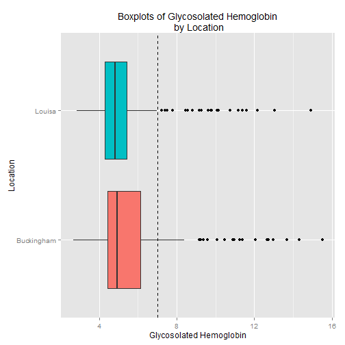

```r
ggplot(data, aes(x = location, y = glyhb)) +
  geom_boxplot(aes(fill = location)) +
  coord_flip() +
  theme(legend.position="none") +
  ylab("Glycosolated Hemoglobin") +
  xlab("Location") +
  ggtitle("Boxplots of Glycosolated Hemoglobin\n by Location") +
  geom_hline(yintercept = 7, linetype = "dashed")
```

Now let's make them for Gender.

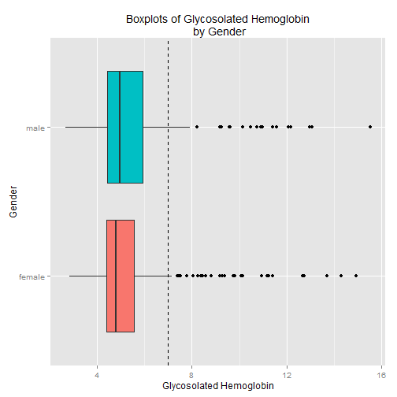

```r
ggplot(data, aes(x = gender, y = glyhb)) +
  geom_boxplot(aes(fill = gender)) +
  coord_flip() +
  theme(legend.position="none") +
  ylab("Glycosolated Hemoglobin") +
  xlab("Gender") +
  ggtitle("Boxplots of Glycosolated Hemoglobin\n by Gender") +
  geom_hline(yintercept = 7, linetype = "dashed")
```

## Question 5

First let's create the BMI and WHR variables and then add them to our data frame.

```r
data$BMI = 703 * (data$weight / (data$height)^2)
data$WHR = data$waist / data$hip
```

Now let's compute their empirical distributions. Let's make one for BMI first.

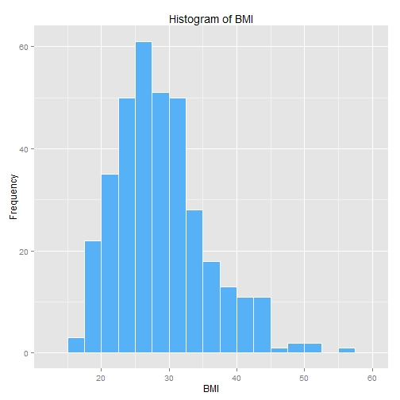

```r
ggplot(data) + geom_histogram(aes(x = BMI), binwidth = 2.5, col = "white", fill = "#56B1F7") +
  ggtitle("Histogram of BMI") +
  xlab("BMI") + ylab("Frequency")
```

Now let's make one for WHR.

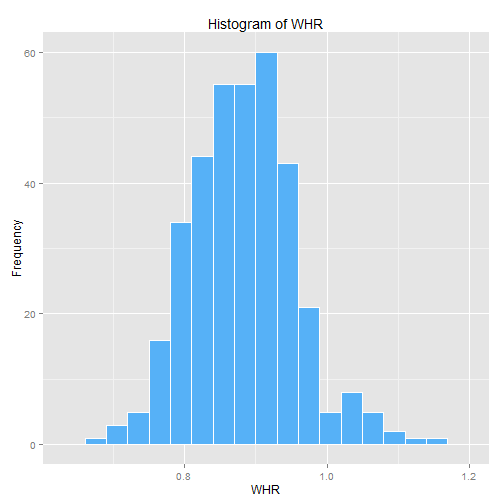

```r
ggplot(data) + geom_histogram(aes(x = WHR), binwidth = 0.03, col = "white", fill = "#56B1F7") +
  ggtitle("Histogram of WHR") +
  xlab("WHR") + ylab("Frequency")
```

Now let's compute their conditional boxplots of glyhb. Let's make one for BMI first.

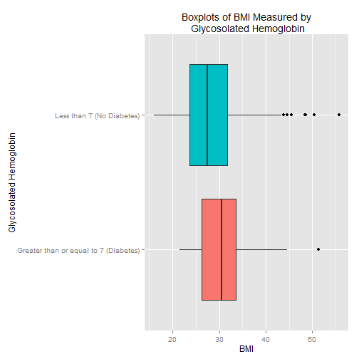

```r
ggplot(data, aes(x = diabetes, y = BMI)) +
  geom_boxplot(aes(fill = diabetes)) +
  coord_flip() +
  theme(legend.position="none") +
  ylab("BMI") +
  xlab("Glycosolated Hemoglobin") +
  ggtitle("Boxplots of BMI Measured by\n Glycosolated Hemoglobin")
```

Now let's make one for WHR.

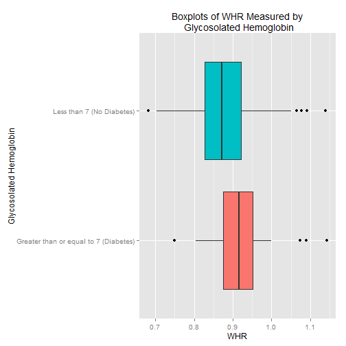

```r
ggplot(data, aes(x = diabetes, y = WHR)) +
  geom_boxplot(aes(fill = diabetes)) +
  coord_flip() +
  theme(legend.position="none") +
  ylab("WHR") +
  xlab("Glycosolated Hemoglobin") +
  ggtitle("Boxplots of WHR Measured by\n Glycosolated Hemoglobin")
```

## Question 6

There does seem to be a difference in cholesterol level between those who have diabetes and those who do not. Though this feature looks like it is related to the presence of type-II diabetes, it might not be the best predictor we have.

The difference in stabilized glucose level between those who have and do not have diabetes seems very significant. Not only are the distributions centered at different values, but their variances differ greatly as well.

HDL is similar to cholesterol in the sense that there does seem to be a difference between people who have and do not have diabetes. Once again, this might not be the most telling indicator, but there does seem to be a relationship.

The ratio of cholesterol to HDL seems lower for those who do not have diabetes. Overall, ratio seems like it has potential to be related to type-II diabetes but we would have to analyze the data more to know for sure.

Age seems very related to the presence of type-II diabetes. The average age for those with diabetes seems much higher than the average age for those without. The variance of the ages of those without diabetes is higher than the variance of those without.

Height seems almost identical among both groups. It does not seem very relevant to the presence of diabetes. Since type-II diabetes is related to obesity, we should pay more attention to the ratio of height to weight instead of height alone.

It does seem that those with diabetes have a higher weight than those without. However, once again, a ratio of height to weight should be a better indicator. Someone might have a very high weight but also be very tall, meaning that they are not necessarily unhealthy.

First systolic blood pressure is higher for those with diabetes than those without. The distribution of first systolic blood pressure for those without diabetes takes on a larger range. It seems that this feature is significant.

The boxplots of first diastolic blood pressure seem to overlap a lot so the feature does not seem that related to the presence of type-II diabetes.

At a first glance, waist size seems quite relevant to diabetes. At the same time, looking at a ratio of waist to hip size is more informative and this might be a better indicator.

The boxplots of hip size for each group once again overlap a lot. Hip circumference on its own might not be the most telling feature.

The boxplots of postprandial time for the two groups are close to identical. This feature is not related to the presence of type-II diabetes.

Location does not seem relevant to whether or not a person has type-II diabetes.

Gender does not seem related to the presence of type-II diabetes. The distributions of glycosolated hemoglobin level are similar for both genders.

BMI seems different between those who have diabetes and those who do not. A higher BMI is related to the presence of diabetes. BMI is a ratio, so it gives us information about both height and weight.

WHR also looks relevant to type-II diabetes. The boxplots seem fairly distinct. Because this is a ratio of two seemingly predictive features, it seems like a good indicator.

# Part 3: Parametric Inference

## Question 1:

Let's fit BMI to a Gamma distribution. There are two parameterizations of this. We will use the one with alpha and beta.

First we begin by finding the expected values of the first and second moments.

```r
bmi = data$BMI
e1 <- mean(bmi)
e1
```

```r
## [1] 28.84369
```

```r
e2 <- mean(bmi^2)
e2
```

```r
## [1] 877.1068
```

Next, we will use these values to find alpha and beta by setting them equal to the true moments.

```r
b <- e1/(e2 - e1^2)
b
```

```r
## [1] 0.6388641
```

```r
a <- e1^2/(e2 - e1^2)
a
```

```r
## [1] 18.4272
```

Now we will use a non-parametric bootstrap to find confidence intervals around alpha and beta. Let's first find all our values of alpha and beta.

```r
gamma.est <- matrix(0, 1000, 2)
for (i in 1:1000) {
  boot <- sample(bmi, 1000, replace = T)
  e1 <- mean(boot)
  e2 <- mean(boot^2)
  gamma.est[i,1] <- e1^2/(e2 - e1^2)
  gamma.est[i,2] <- e1/(e2 - e1^2)
}
```

Now we can compute our 95% confidence intervals for each parameter. We will compute a percentile confidence interval.

For alpha, our 95% CI is:

```r
pboot.perc.a <- quantile(gamma.est[,1], probs = c(0.025, 0.975))
pboot.perc.a
```

```r
##     2.5%    97.5%
## 16.86050 20.12332
```

For beta, our 95% CI is:

```r
pboot.perc.b <- quantile(gamma.est[,2], probs = c(0.025, 0.975))
pboot.perc.b
```

```r
##      2.5%     97.5%
## 0.5833264 0.7045553
```

Lastly, let's fit our Gamma distribution to our empirical histogram.

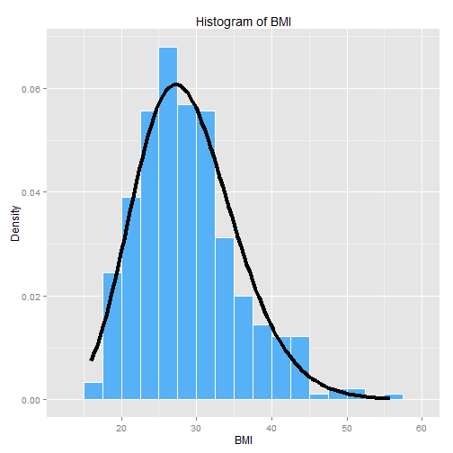

```r
ggplot(data) + geom_histogram(aes(x = BMI, y = ..density..), binwidth = 2.5, col = "white", fill = "#56B1F7") +
  stat_function(fun = dgamma, args = list(shape = a, rate = b), size = 1.5) +
  ggtitle("Histogram of BMI") +
  xlab("BMI") + ylab("Density")
```

## Question 2

Let's fit WHR to a Gaussian distribution.

First let's solve for the MLE of the mean and the variance.

```r
whr = data$WHR
mle.u <- mean(whr)
mle.u
```

```r
## [1] 0.8821109
```

```r
mle.sig <- sqrt(mean((whr - mle.u)^2))
mle.sig
```

```r
## [1] 0.07373207
```

Now let's use nonparametric bootstrap to generate our means and variances.

```r
whr.est <- matrix(0, 1000, 2)
for (i in 1:1000) {
boot <- sample(whr, 1000, replace = T)
      whr.est[i,1] <- mean(boot)
     whr.est[i,2] <- var(boot)
}
```

Now let's find our 95% CI for the mean and variance.

```r
pboot.perc.mean <- quantile(whr.est[,1], probs = c(0.025, 0.975))
pboot.perc.mean
```

```r
##      2.5%     97.5%
## 0.8776218 0.8868247
```

```r
pboot.perc.var <- quantile(whr.est[,2], probs = c(0.025, 0.975))
pboot.perc.var
```

```r
##        2.5%       97.5%
## 0.004868077 0.005978904
```

Lastly, let's fit our Gaussian distribution to our empirical histogram.

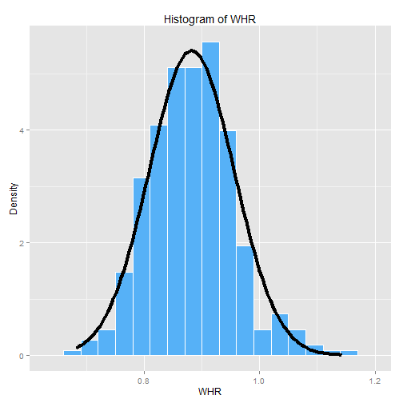

```r
ggplot(data) + geom_histogram(aes(x = WHR, y = ..density..), binwidth = 0.03, col = "white", fill = "#56B1F7") +
  stat_function(fun = dnorm, args = list(mean = mle.u, sd = mle.sig), size = 1.5) +
  ggtitle("Histogram of WHR") +
  xlab("WHR") + ylab("Density")
```